# 第2回 ミクロ/マクロ①：企業財務比率

経済データ入門

第2回

ミクロ/マクロ①：企業財務比率

絶対額では比べられない。相対（比率）  
にそろえて、はじめて比べられる

経済データ入門

第2回 — Topic01

有価証券報告書と流動比率

会社の数字の出どころを確かめて、1 回割る

## この回の道のり

1

有報と流動比率

演習 2-1

単位と流動負債

2

利益率と ROE

演習 2-2

利益と元手の半減

3

増減率

演習 2-3

前期売上の増加

4

棒とレーダー

演習 2-4

棒と指数と形の変化

いまここ — 会社の数字の出どころを確かめて、1 回割る

## 前回の振り返り

前回のポイント — 第1回「統計データの出所と出典の明示」

Q: 数字の身元を言える型は、何だったか

- **出典 4 点セット**：作成機関・統計名と調査年・表名・取得日
- **データカード 7 項目**：統計名から出典の 1 行まで、上から埋める
- **EDINET の 3 歩**：会社名 → 書類の一覧 → 「経理の状況」

今日は会社の数字の出どころを確かめて、1 回割る

## 「比率」シートで作る所

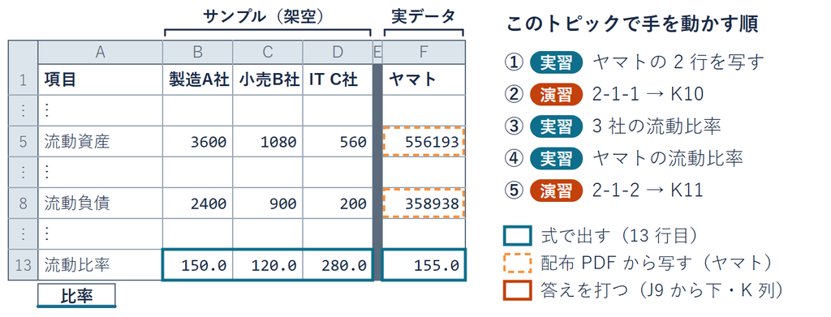

置き場は演習ブック lec2-exercise.xlsx の「比率」シート

3 社の 5・8 行目は入っている。ヤマトの 2 行は自分で写す

## 単体と連結の囲み方

[figure not shown]

- **サンプルデータ**：架空の会社グループ。  
  グループ内の貸し借りは無いとする
- **流動資産**：1 年以内に現金になる財産（預金・売掛金など）

## 連結・単体・単位

用語

**連結**＝親会社と子会社をまとめた、グループ全体の数字  
**単体**＝親会社 1 社だけの数字

- **単位**：右上の「（単位：億円）」。200 は 200 億円のこと
- **この授業で読むのは連結**：ニュースの会社の数字も、ふつう連結

同じ社名でも、どこまで含めた数字かで変わる

## ヤマトの連結貸借対照表

有価証券報告書の配布 PDF（全 151 ページ）の 81〜82 ページ目  
『lecture02_有価証券報告書_ヤマトHD_2026年3月期.pdf』

| ヤマト 第161期の行（連結） | 当期（百万円） |
| --- | --- |
| 流動資産合計（1 年以内にお金になる財産） | 556,193 |
| 流動負債合計（1 年以内に返すお金） | 358,938 |

- **有価証券報告書**：上場企業が法律にもとづき年 1 回出す報告書
- **単位**：右上の「（単位：百万円）」。556,193 百万円のこと
- **単体なら**：流動資産合計は 96,080（129 ページ目）。連結は約 5.8 倍
- **この授業の数**：配布 PDF の値。EDINET の新しい年とは違ってよい

出典：ヤマトホールディングス 有価証券報告書（第161期）

## ヤマトの 2 行の転記

1. **開く**：連結貸借対照表  
   （配布 PDF の 81・82 ページ目）
2. **写す**：2 行を F5・F8 へ  
   カンマは打たずに数字だけ

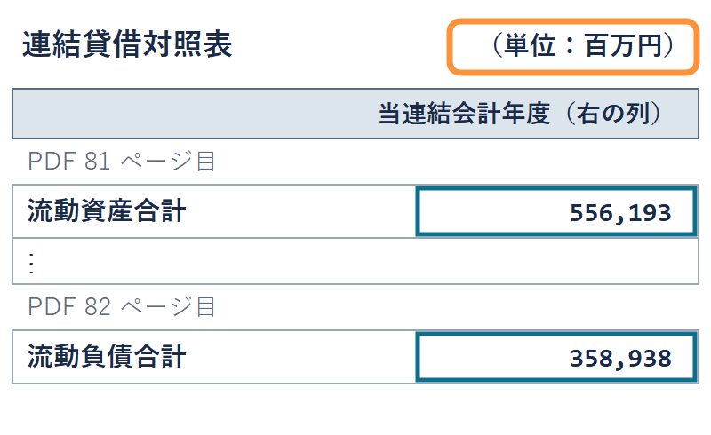

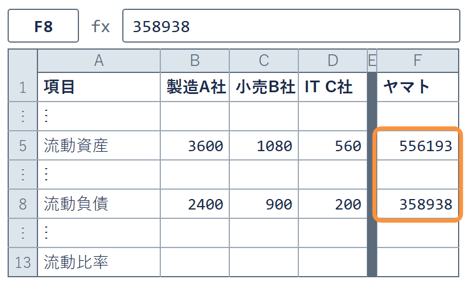

単位は百万円のまま写す。右上の単位も一緒に確かめる

✋ 動画を止めて STEP 1・2 を進め、F8 が 358938 なら再生に戻る

## 演習 2-1-1 千円の単位

演習 2-1-1

表の右上が（単位：千円）なら、556,193 は何円か

1. **見る場所**：表の右上の単位（ここでは千円とする）
2. **考える問い**：556,193 に何を掛けると円になるか
3. **答えを打つ**：K10（演習 2-1-1 の行）に、円の数字を打つ
4. **終わりの条件**：K10 に打ち、「何億何万」と読める

✋ 動画を止めて 1 分。K10 に打ったら再生に戻る

## 演習 2-1-1 の答え

演習 2-1-1 の答え

556,193,000 円（5 億 5,619 万 3 千円）

- **式の中身**：556,193 × 1,000 ＝ 556,193,000
- **百万円なら**：同じ 556,193 が 5,561 億 9,300 万円
- **読み方**：同じ数字でも、単位が違えば 1,000 倍ちがう
- **答え欄**：K10 に 556193000 と打てていれば正解

## 流動資産と流動負債の高さ

[figure not shown]

- **サンプルデータ**：架空。lec2-exercise.xlsx の「比率」シート
- **目盛り**：会社ごとに違う

✋ 予想する — 手元の余裕が厚いのは 製造 A 社／小売 B 社／IT C 社

## 流動比率の定義

定義

**流動比率 ＝ 流動資産 ÷ 流動負債 × 100**  
1 年以内に返す 100 円に、手元の財産が何円あるか

- **製造 A 社**：3,600 ÷ 2,400 × 100 ＝ 150.0
- **読み方**：100 を下回ると、手元だけでは返しきれない目安
- **目安は目安**：ふつうの水準は業種で違う

額の大きさではなく、払う分に対する手元の厚さを見る

## 3 社の流動比率

1. **式を打つ**：B13 に  
   `=B5/B8*100`
2. **右へ引く**：B13 の右下の  
   四角を D13 まで
3. **そろえる**：`Ctrl + 1` の「数値」  
   で小数点以下を 1 桁に

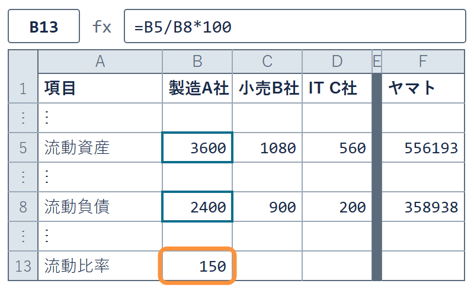

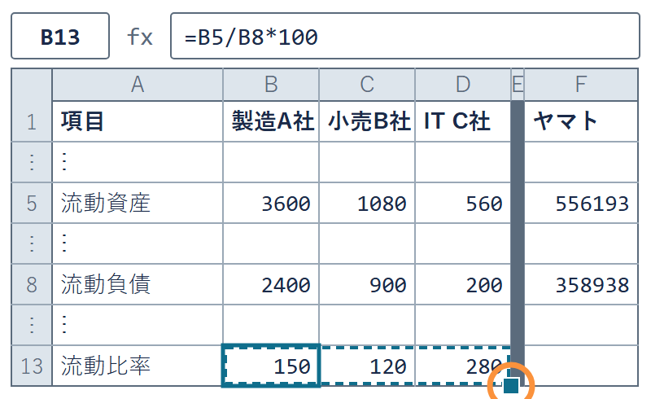

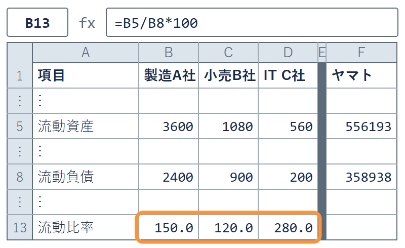

流動資産は 5 行目、流動負債は 8 行目。Mac は `⌘ + 1`

✋ 動画を止めて STEP 1〜3 を進め、D13 が 280.0 なら再生に戻る

## ヤマトの流動比率

1. **コピー**：D13 をコピーし  
   F13 を選ぶ
2. **貼る**：F13 に貼ると  
   `=F5/F8*100` になる

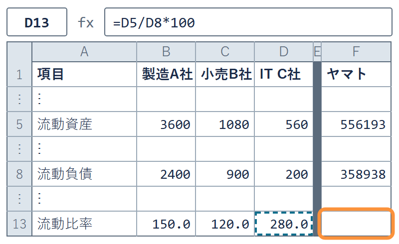

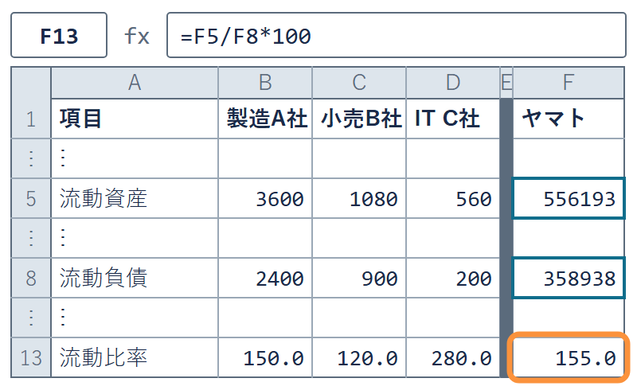

F 列はヤマトの実データ。556,193 ÷ 358,938 × 100 → 155.0

✋ 動画を止めて STEP 1・2 を進め、F13 が 155.0 なら再生に戻る

## 演習 2-1-2 流動負債の増加

演習 2-1-2

製造 A 社の流動負債だけが増えると、流動比率はいくつか

1. **変える場所**：B8（製造 A 社の流動負債）を 2,400 から 3,600 に
2. **考える問い**：B13 はいくつになるか。先に予想してから打つ
3. **答えを打つ**：K11（演習 2-1-2 の行）に、B13 の値を打つ
4. **終わりの条件**：K11 に打ったら、B8 を 2,400 に戻す

✋ 動画を止めて 2 分。K11 に打ち、B8 を戻したら再生に戻る

## 演習 2-1-2 の答え

演習 2-1-2 の答え

B13 は 100.0（流動資産と流動負債が同じ額）

- **式の中身**：3,600 ÷ 3,600 × 100 ＝ 100.0
- **動いたのは B13 だけ**：いま B8 を使っている式はこの 1 本
- **読み方**：1 年以内に返す額と、手元がちょうど同じ
- **答え欄**：K11 に 100.0 と打てていれば正解

## 有報のデータカード

| 項目 | 有価証券報告書の例（ヤマトホールディングス） |
| --- | --- |
| 統計名・表番号 | 会社名と事業年度 — 第161期の**連結貸借対照表** |
| 作成機関 | 各企業が作成・提出（開示は金融庁の EDINET） |
| 調査の種類 | 統計調査ではなく、会社が**法律にもとづいて**出す・年 1 回 |
| 単位・基準 | 百万円・**連結**（グループ全体） |
| 定義の落とし穴 | 単体の 96,080 と取り違えない。ほかに**自分で気づいたこと**を 1 つ |
| 入手先・取得日 | EDINET（または配布 PDF）・**提出日と、自分が開いた日**の両方 |
| 出典 4 点セット | ヤマトホールディングス株式会社 「有価証券報告書（第161期・2026年3月期）」 連結貸借対照表 （78〜79頁・PDF 81〜82 ページ目）、2026年9月22日取得 |

欄は第1回と同じ 7 つ

## 生成 AI の答えと有報の照合

聞き方の例  
「〔会社名〕の 2026年3月期の有価証券報告書の連結貸借対照表で  
流動資産合計と流動負債合計はいくらですか  
事業年度と単位、載っている表の名前もあわせて教えてください」

- **順番**：自分で読んで割ってから、AI に聞く
- **見るところ**：事業年度・連結か単体か・単位・表の名前・数字
- **合わないとき**：① 自分の読み違い → ② 連結と単体・単位 → ③ AI の誤り

答え合わせの相手は、AI ではなく自分で開いた有報

次は、同じ割り算で会社の稼ぐ力をそろえる

経済データ入門

第2回 — Topic02

利益率と自己資本利益率

売上 100 円あたり、元手 100 円あたりにそろえて比べる

## この回の道のり

1

有報と流動比率

演習 2-1

単位と流動負債

2

利益率と ROE

演習 2-2

利益と元手の半減

3

増減率

演習 2-3

前期売上の増加

4

棒とレーダー

演習 2-4

棒と指数と形の変化

いまここ — 利益を売上・元手 100 円あたりにそろえる

## 「比率」シートの完成形

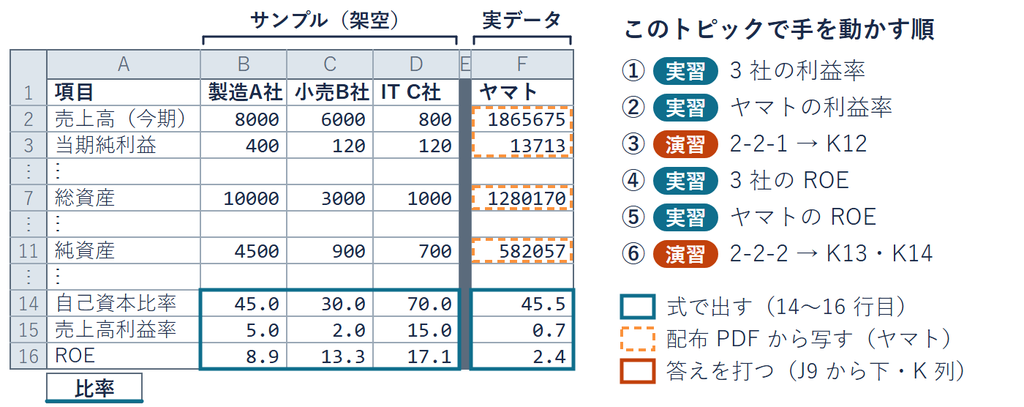

置き場は演習ブック lec2-exercise.xlsx の「比率」シート

分子は同じ利益。何で割るかで、見える姿が変わる

## 就職先 3 社の成績表

| 会社（架空） | 売上高 | 当期純利益 |
| --- | --- | --- |
| 製造 A 社 | 8,000 億円 | 400 億円 |
| 小売 B 社 | 6,000 億円 | 120 億円 |
| IT C 社 | 800 億円 | 120 億円 |

- **サンプルデータ**：架空。lec2-exercise.xlsx の「比率」シート
- **当期純利益**：1 年の売上から、費用と税をすべて引いて残った額
- **問い**：売上 100 円あたりで、いちばん多く利益が残るのはどこか

✋ 動画を止めて予想する — 製造 A 社／小売 B 社／IT C 社

## 売上 100 円あたりへの割り算

1 社ずつ、当期純利益を売上高で割って 100 倍する

- **製造 A 社**：400 ÷ 8,000 × 100 ＝ 5.0 円
- **小売 B 社**：120 ÷ 6,000 × 100 ＝ 2.0 円
- **IT C 社**：120 ÷ 800 × 100 ＝ 15.0 円

いちばん利益の少ない IT C 社が、売上 100 円あたりではいちばん多い

## 利益率の棒と順位の入れ替わり

[figure not shown]

同じ 120 億円でも、分母の売上高が 7.5 倍ちがう

- **サンプルデータ**：lec2-exercise.xlsx の「比率」シート

## 利益率の定義

定義

**利益率（ROS）＝ 当期純利益 ÷ 売上高 × 100**  
売上 100 円あたりに、何円の利益が残るか

- **絶対額**：そのままの金額。利益の額なら製造 A 社が上
- **相対**：何かあたりに直した値。利益率なら IT C 社が上
- **ROS**：売上高利益率の英語の頭文字

絶対額では比べられない  
相対にそろえて、はじめて比べられる

## 3 社の利益率

1. **式を打つ**：B15 に  
   `=B3/B2*100`
2. **右へ引く**：B15 の右下の  
   四角を D15 まで
3. **そろえる**：`Ctrl + 1` の「数値」  
   で小数点以下を 1 桁に

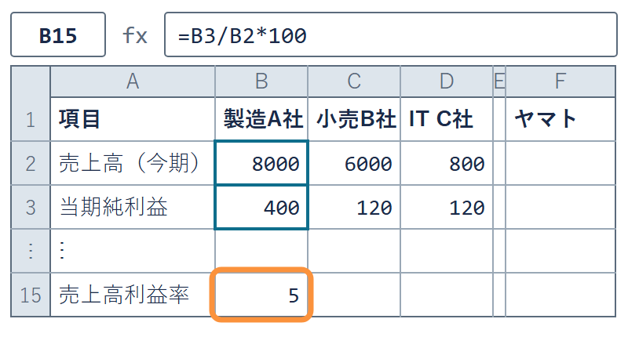

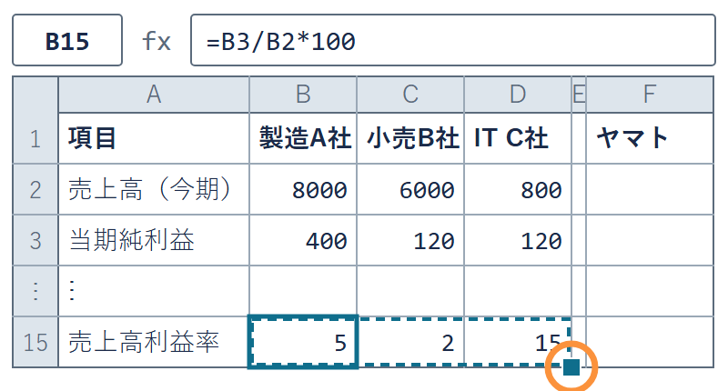

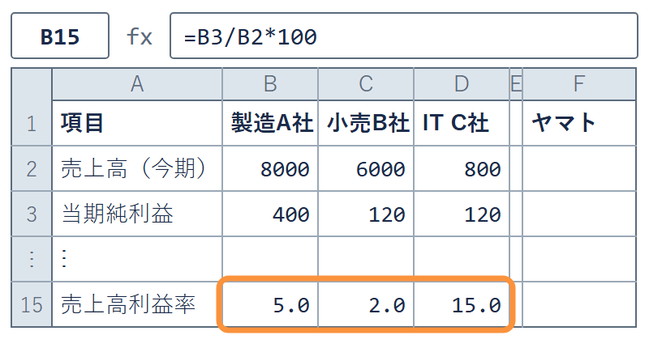

売上高は 2 行目、当期純利益は 3 行目。Mac は `⌘ + 1`

✋ 動画を止めて STEP 1〜3 を進め、D15 が 15.0 なら再生に戻る

## ヤマトの連結損益計算書

配布 PDF『lecture02_有価証券報告書_ヤマトHD_2026年3月期.pdf』  
84〜85 ページ目の連結損益計算書から読む

| ヤマト 第161期の行 | 当期（百万円） |
| --- | --- |
| 営業収益（いちばん上の行） | 1,865,675 |
| 当期純利益 | 13,713 |
| 利益率 | 13,713 ÷ 1,865,675 × 100 → **0.7%** |

- **行の名前**：売上高の行が「営業収益」。いちばん上の行を読む
- **読み方**：売上 100 円あたり、約 0.7 円の利益が残る

出典：ヤマトホールディングス 有価証券報告書（第161期）

## ヤマトの利益率

1. **写す**：PDF 84・85 ページ目の  
   2 行を F2・F3 へ
2. **貼る**：D15 をコピーし  
   F15 に貼る

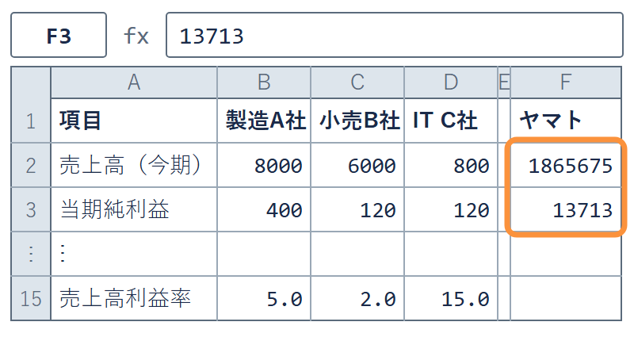

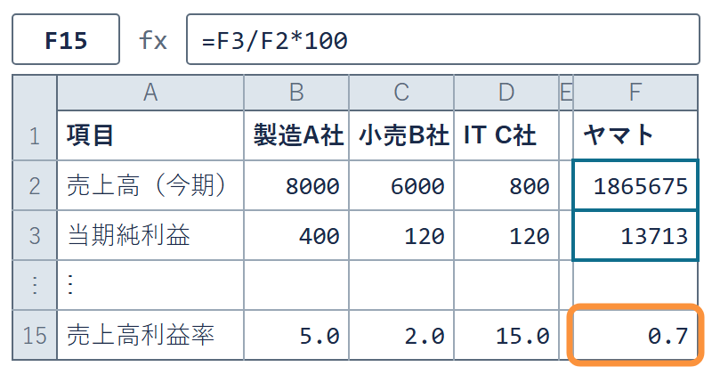

単位は百万円のまま写してよい（割る 2 つが同じ単位）

✋ 動画を止めて STEP 1・2 を進め、F15 が 0.7 なら再生に戻る

## 演習 2-2-1 利益の半減

演習 2-2-1

IT C 社の利益だけを半分にすると、利益率はいくつか

1. **変える場所**：D3（IT C 社の当期純利益）を 120 から 60 に
2. **考える問い**：D15 はいくつになるか。先に予想してから打つ
3. **答えを打つ**：K12（演習 2-2-1 の行）に、D15 の値を打つ
4. **終わりの条件**：K12 に打ったら、D3 を 120 に戻す

✋ 動画を止めて 2 分。K12 に打ち、D3 を戻したら再生に戻る

## 演習 2-2-1 の答え

演習 2-2-1 の答え

D15 は 7.5（分子が半分・分母の 800 は同じ）

- **式の中身**：60 ÷ 800 × 100 ＝ 7.5
- **動いたのは D15 だけ**：いま D3 を使っている式はこの 1 本
- **読み方**：売上が同じなら、利益が半分で利益率も半分
- **答え欄**：K12 に 7.5 と打てていれば正解

## 元手に対する利益

| 会社（架空） | 当期純利益 | 純資産 |
| --- | --- | --- |
| 製造 A 社 | 400 億円 | 4,500 億円 |
| 小売 B 社 | 120 億円 | 900 億円 |
| IT C 社 | 120 億円 | 700 億円 |

- **サンプルデータ**：架空。lec2-exercise.xlsx の「比率」シート
- **純資産**：返さなくてよいお金。株主の元手と、利益の積み上げ
- **問い**：利益率で最下位の小売 B 社は、元手 100 円あたりでは何位か

✋ 動画を止めて予想する — 1 位／2 位／3 位のまま

## 純資産と自己資本比率

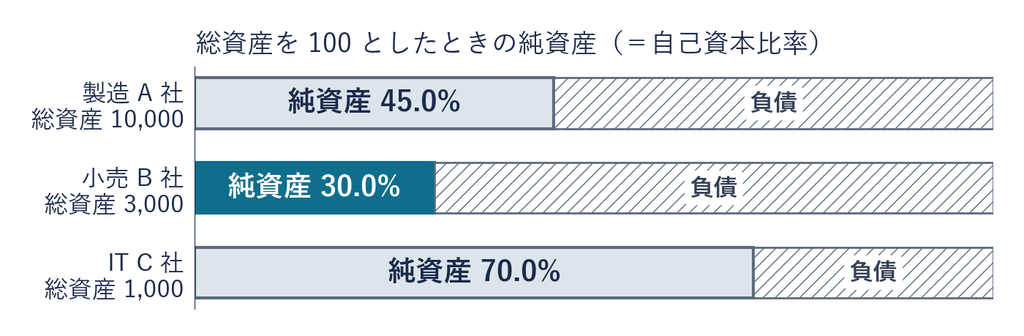

- **総資産**：会社の財産の合計。そのうち返さなくてよい分が純資産
- **サンプルデータ**：lec2-exercise.xlsx の「比率」シート

小売 B 社は 30.0% で、元手がいちばん薄い

## 分母の付け替えと ROE

[figure not shown]

分母を純資産に替えると、小売 B 社は 2 位に上がる

- **サンプルデータ**：lec2-exercise.xlsx の「比率」シート

## ROE の定義

定義

**ROE ＝ 当期純利益 ÷ 純資産 × 100**  
**自己資本比率 ＝ 純資産 ÷ 総資産 × 100**

- **ROE**：自己資本利益率。元手 100 円あたりに、何円の利益が残るか
- **自己資本比率**：財産 100 円のうち、返さなくてよいお金がいくらか
- **この授業の簡略版**：分母は期末の純資産。公表の ROE とは定義が違う

自己資本比率では分子の純資産が、ROE では分母に来る

## 3 社の ROE と自己資本比率

1. **式を打つ**：B16 に  
   `=B3/B11*100`
2. **右へ引く**：B16 を右下の四角で  
   D16 まで引きのばす
3. **分母の説明**：B14 に  
   `=B11/B7*100`・D14 まで
4. **そろえる**：B14:D16 で  
   `Ctrl + 1`（Mac は `⌘ + 1`）  
   → 数値・小数点以下 1 桁

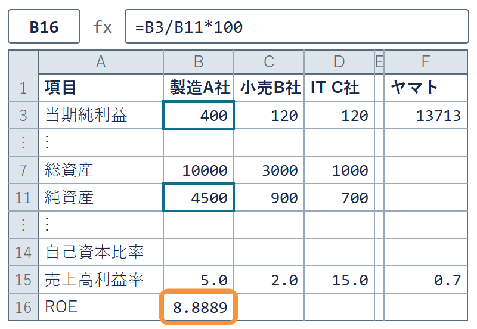

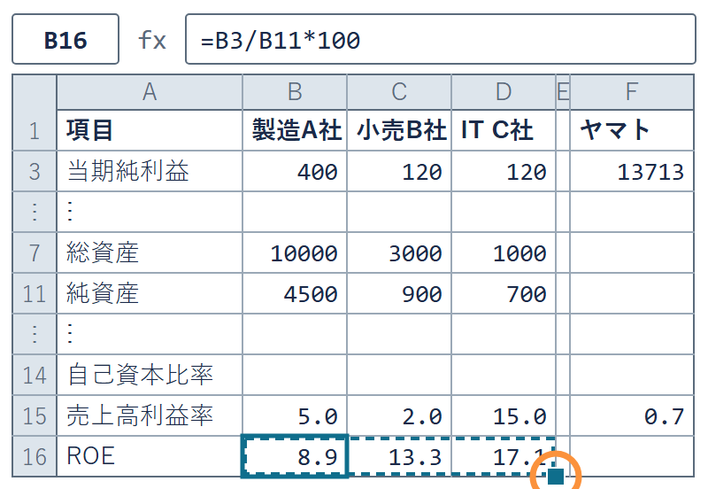

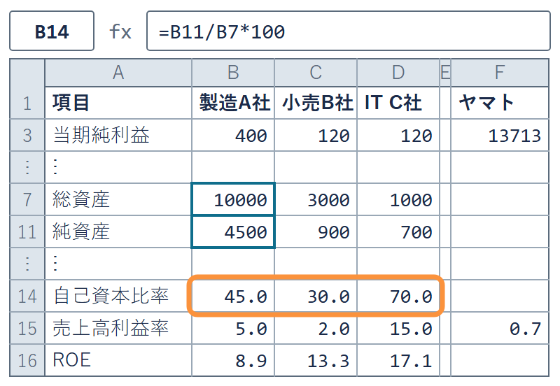

✋ 動画を止めて STEP 1〜4 を進め、D16 が 17.1 なら再生に戻る

## ヤマトの ROE

| 読む行 | 当期（百万円） |
| --- | --- |
| 当期純利益（損益計算書） | 13,713 |
| 純資産合計（貸借対照表） | 582,057 |
| 資産合計（貸借対照表） | 1,280,170 |

- **ROE**：13,713 ÷ 582,057 × 100 → 2.4%
- **自己資本比率**：582,057 ÷ 1,280,170 × 100 → 45.5%

出典：ヤマトホールディングス 有価証券報告書（第161期）

## ヤマトの ROE を出す

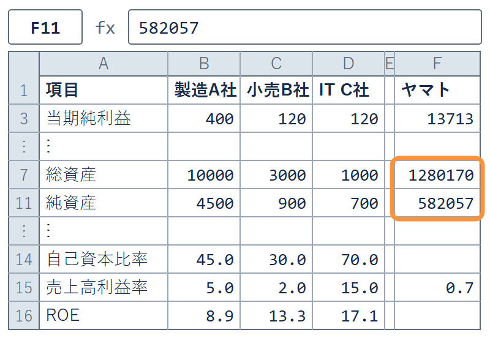

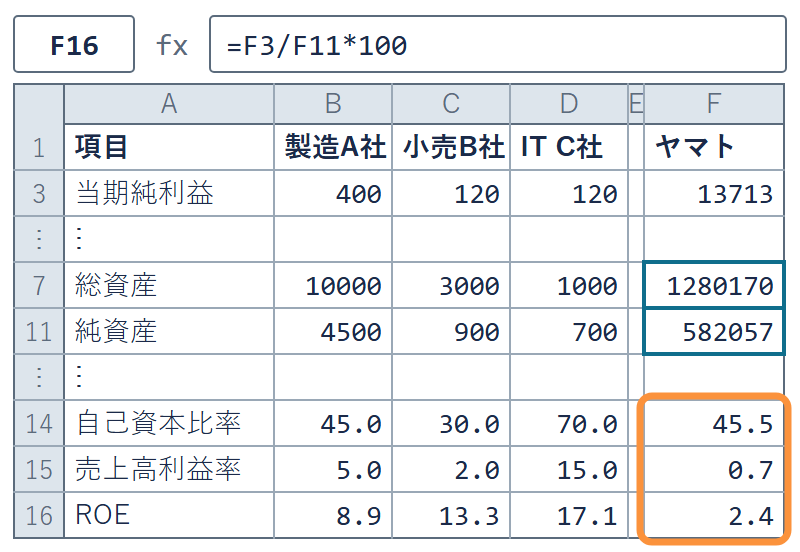

✋ 動画を止めて STEP 1・2 を進め、F16 が 2.4 なら再生に戻る

## 演習 2-2-2 元手の半減

演習 2-2-2

IT C 社の純資産だけを半分にすると、ROE はいくつか

1. **変える場所**：D11（IT C 社の純資産）を 700 から 350 に
2. **考える問い**：D16 はいくつか。D14 はどう動くか
3. **答えを打つ**：K13 に D16、K14 に D14 の値を打つ（演習 2-2-2 の 2 行）
4. **終わりの条件**：K13・K14 に打ったら、D11 を 700 に戻す

✋ 動画を止めて 2 分。K13・K14 に打ち、D11 を戻したら再生に戻る

## 演習 2-2-2 の答え

演習 2-2-2 の答え

D16 は 34.3（分母が半分で ROE は 2 倍）

- **式の中身**：120 ÷ 350 × 100 → 34.3
- **D14 も動く**：35.0 に下がる。元手が薄いほど ROE は高く出る
- **考え方**：減った元手は借入で埋めたと考え、総資産の 1,000 は変えない
- **答え欄**：K13 に 34.3、K14 に 35.0 と打てていれば正解

## Q&A

Q1 利益率が 500.0% と出た

パーセンテージ表示を外し、**数値・小数第 1 位**に。100 倍は式だけ

Q2 売上高の行が見つからない

損益計算書の**いちばん上の行**を読む。ヤマトでは「営業収益」

Q3 ROE の分母に総資産の B7 を使った

分母は純資産の **B11**。総資産で割ると別の指標になる

## まとめ

- **絶対額と相対**：利益の額の順位は、割り算 1 回で入れ替わる
- **利益率**：当期純利益 ÷ 売上高 × 100（ヤマトは 0.7%）
- **ROE**：当期純利益 ÷ 純資産 × 100（ヤマトは 2.4%）
- **自己資本比率**：純資産 ÷ 総資産 × 100 で、元手の厚さを見る
- **分母まで言う**：同じ利益でも、何で割ったかで姿が変わる

次は、同じ割り算で前の年と比べる

経済データ入門

第2回 — Topic03

前年比と増減率

差を前の年で割って比べる

## この回の道のり

1

有報と流動比率

演習 2-1

単位と流動負債

2

利益率と ROE

演習 2-2

利益と元手の半減

3

増減率

演習 2-3

前期売上の増加

4

棒とレーダー

演習 2-4

棒と指数と形の変化

いまここ — 差を前の年で割って比べる

## 「比率」シートで作る所

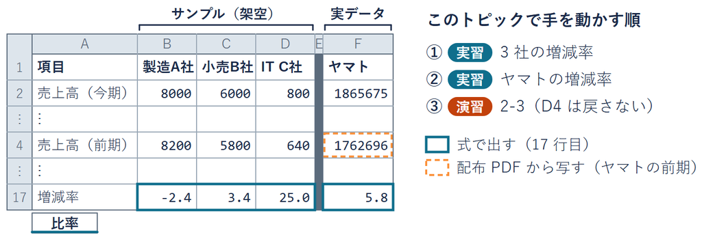

置き場は演習ブック lec2-exercise.xlsx の「比率」シート

3 社の 2・4 行目は入っている。ヤマトの前期は自分で写す

## 3 社の売上高の今期と前期

| 会社（架空） | 今期の売上高 | 前期の売上高 |
| --- | --- | --- |
| 製造 A 社 | 8,000 億円 | 8,200 億円 |
| 小売 B 社 | 6,000 億円 | 5,800 億円 |
| IT C 社 | 800 億円 | 640 億円 |

- **サンプルデータ**：架空。lec2-exercise.xlsx の「比率」シート
- **今期と前期**：今年とその 1 年前。シートの 2 行目と 4 行目
- **問い**：前の年から、売上がいちばん大きく伸びたのはどこか

✋ 動画を止めて予想する — 製造 A 社／小売 B 社／IT C 社

## 前期と今期の売上高の棒

[figure not shown]

差は −200・＋200・＋160（億円）

- **サンプルデータ**：lec2-exercise.xlsx の「比率」シート

## 差を前期で割る計算

1 社ずつ、差を前期の売上高で割って 100 倍する

- **製造 A 社**：−200 ÷ 8,200 × 100 → −2.4
- **小売 B 社**：200 ÷ 5,800 × 100 → 3.4
- **IT C 社**：160 ÷ 640 × 100 ＝ 25.0

前の年の売上 100 円あたり、何円増えたかを見る

## 差の棒と増減率の棒

[figure not shown]

動いた額がいちばん小さい IT C 社が、率ではいちばん大きい

- **サンプルデータ**：lec2-exercise.xlsx の「比率」シート

## 増減率の定義

定義

**増減率 ＝ (今期 − 前期) ÷ 前期 × 100**  
前の年の 100 円あたりに、何円増えたか

- **割る相手**：必ず前期。もとにした年の大きさで割る
- **前年比**：IT C 社なら「前年比 25.0% 増」と言う
- **減ったとき**：製造 A 社の −2.4 のように負になる

差の額ではなく、前の年に対する割合で比べる

## 3 社の増減率

1. **式を打つ**：B17 に  
   `=(B2-B4)/B4*100`
2. **右へ引く**：B17 の右下の  
   四角を D17 まで
3. **そろえる**：`Ctrl + 1` の「数値」  
   で小数点以下を 1 桁に

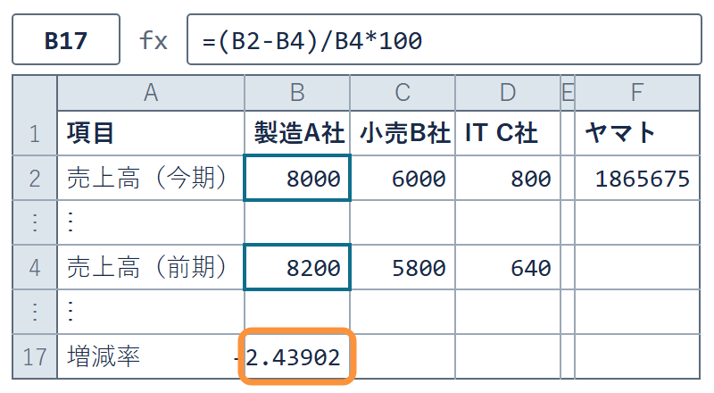

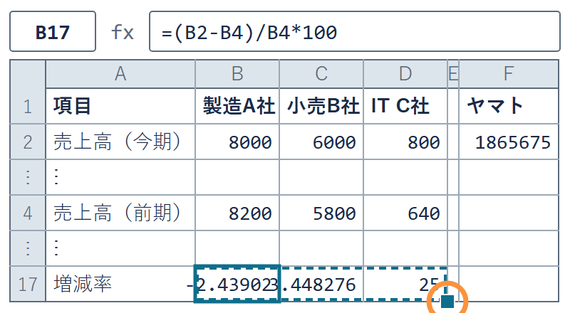

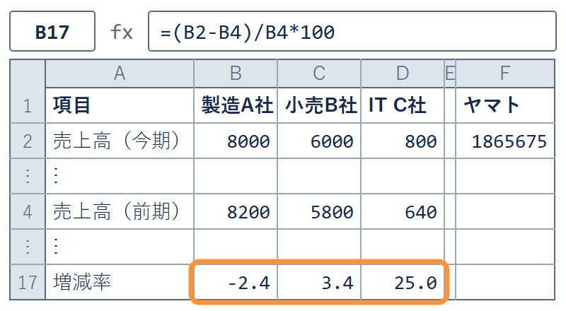

今期は 2 行目、前期は 4 行目。Mac は `⌘ + 1`

✋ 動画を止めて STEP 1〜3 を進め、D17 が 25.0 なら再生に戻る

## 割る相手の取り違え

今期で割る  
`=(B2-B4)/B2*100`  
製造 A 社 **−2.5**・IT C 社 **20.0**

前期で割る（正しい）  
`=(B2-B4)/B4*100`  
製造 A 社 **−2.4**・IT C 社 **25.0**

- **なぜ起きるか**：今期の B2 が目の前にあり、つい B2 で割る
- **どう防ぐか**：数式バーで、分母が 4 行目（前期）かを見る

割る相手は、もとにした年。B17 の分母は B4

## ヤマトの営業収益の 2 期

配布 PDF『lecture02_有価証券報告書_ヤマトHD_2026年3月期.pdf』  
84 ページ目の連結損益計算書、いちばん上の行を読む

| ヤマト 第161期の行 | 百万円 |
| --- | --- |
| 営業収益（前期・左の列） | 1,762,696 |
| 営業収益（当期・右の列） | 1,865,675 |
| 差（当期 − 前期） | 102,979 |
| 増減率 | 102,979 ÷ 1,762,696 × 100 → **＋5.8%** |

- **＋5.8% は率**：前年比 5.8% 増。連結の「約 5.8 倍」とは別の数

出典：ヤマトホールディングス 有価証券報告書（第161期）

## ヤマトの増減率

1. **開く**：PDF 84 ページ目の  
   営業収益の左の列（前期）
2. **写す**：1762696 を F4 へ  
   カンマは打たずに数字だけ
3. **貼る**：D17 をコピーし  
   F17 に貼る

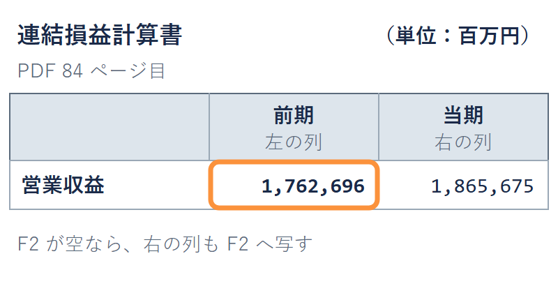

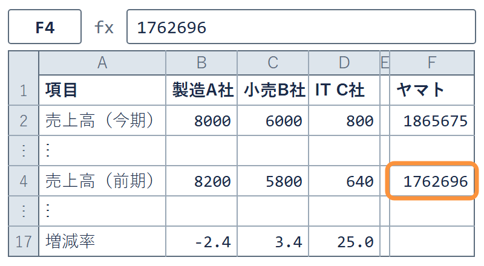

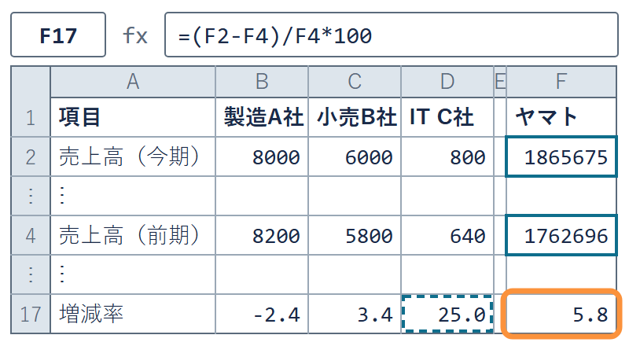

F2 は前のトピックで写した当期の 1,865,675

✋ 動画を止めて STEP 1〜3 を進め、F17 が 5.8 なら再生に戻る

## 演習 2-3 前期売上の増加

演習 2-3

IT C 社の前期の売上高だけが 1,000 億円なら、増減率はいくつか

1. **変える場所**：D4（IT C 社の前期の売上高）を 640 から 1,000 に
2. **考える問い**：D17 はいくつになるか。先に予想してから打つ
3. **終わりの条件**：D17 を確かめたら、D4 は 1,000 のまま残す

✋ 動画を止めて 2 分。D17 を確かめたら、そのまま再生に戻る

## 演習 2-3 の答え

演習 2-3 の答え

D17 は −20.0（今期の 800 が前期の 1,000 より少ない）

- **式の中身**：(800 − 1,000) ÷ 1,000 × 100 ＝ −20.0
- **動いたのは D17 だけ**：いま D4 を使っている式はこの 1 本
- **読み方**：今期が同じでも、前期が大きいと減ったことになる
- **提出**：D4 は 1,000、D17 は −20.0 のままでよい

## まとめ

- **増減率**：割る相手は前期。(今期 − 前期) ÷ 前期 × 100
- **差と率**：動いた額が小さい IT C 社が、率では 25.0 でいちばん大きい
- **ヤマト**：営業収益は前の年より ＋5.8%（前年比 5.8% 増）
- **取り違え**：今期で割ると別の値になる（製造 A 社は −2.5）

次は、そろえた数をグラフにして並べて比べる

経済データ入門

第2回 — Topic04

グラフによる多指標  
比較と指数化

棒で大小を、レーダーで形を見る

## この回の道のり

1

有報と流動比率

演習 2-1

単位と流動負債

2

利益率と ROE

演習 2-2

利益と元手の半減

3

増減率

演習 2-3

前期売上の増加

4

棒とレーダー

演習 2-4

棒と指数と形の変化

いまここ — そろえた数を棒とレーダーで並べる

## 「比率」シートで作る所

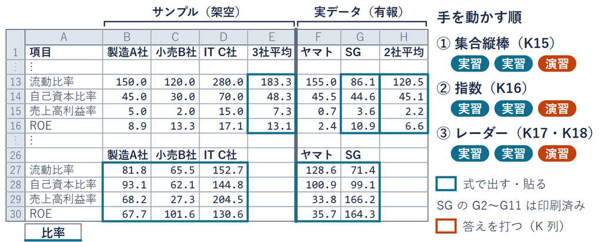

置き場は演習ブック lec2-exercise.xlsx の「比率」シート

SG の元の数 G2〜G11 は印刷済み。G13〜G16 は実習で出す

## 3 社の利益率の棒

[figure not shown]

- **サンプルデータ**：架空。「比率」シートの 15 行目（トピック 2 の値）
- **棒 1 本**：表の値 1 つ。棒の高さが値の大きさ
- **集合縦棒**：項目ごとの値を、棒の高さで並べたグラフ

## 3 社の利益率の棒を描く

1. **選ぶ**：B1:D1 を選び、Ctrl を  
   押しながら B15:D15
2. **描く**：「挿入」タブの  
   縦棒から「集合縦棒」
3. **題**：グラフの題を  
   「売上高利益率（%）」に

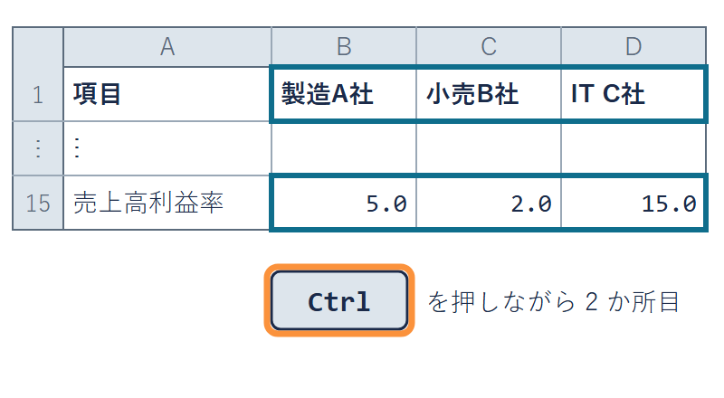

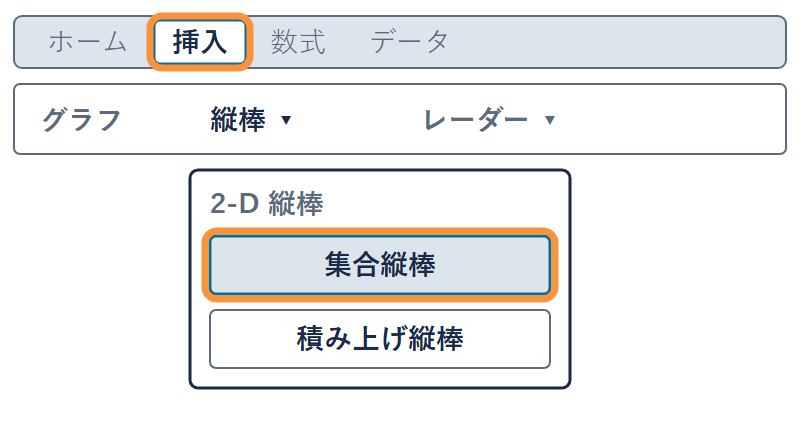

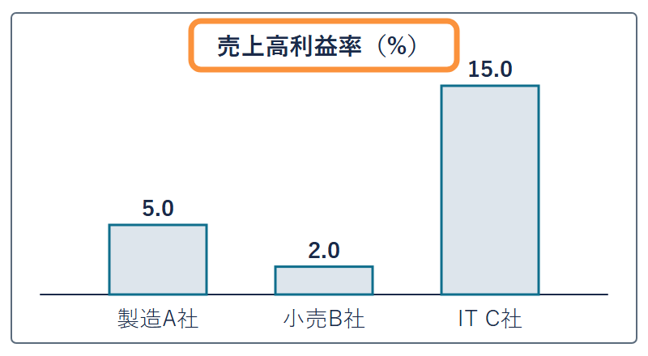

1 行目は会社名、15 行目は利益率。Mac は ⌘ を押しながら

✋ 動画を止めて STEP 1〜3 を進め、棒が 3 本出たら再生に戻る